# BIOS 611 Project 1

Marissa Ashner

9/24/2018

R provides many existing datasets for users to explore, and this project makes use of four of those datasets, as well as the `dplyr` and `ggplot2` libraries to manipulate and visualize different aspects of those data. The datasets were chosen were as follows: `CO2`, `UKLungDeaths`, `sleep`, and `infert`.

The following code is written in order to import the following libraries and datasets into my workspace, so I can utilize them for the remainder of the project.

```r
library(tidyverse)
library(ggplot2)
library(knitr)
data("CO2")
data("UKLungDeaths")
data("sleep")
data("infert")
```

## Dataset 1: CO2

The `CO2` dataset in R is titled **Carbon Dioxide Uptake in Grass Plants**. This dataset was derived from *The statistical analysis of ecophysiological response curves obtained from experiments involving repeated measures*, and was originally a part of the `nlme` package in R. It has 84 rows and 5 columns and is from an experiment on the cold tolerance of a grass species. The CO2 uptake from 12 plants were measured at different levels of ambient CO2 concentration. Half of the plants were from Quebec and half from Mississippi. The first few lines of the dataset are shown in the table below.

```r
head(CO2) %>% kable(align = c("c", "c"))
```

| Plant | Type | Treatment | conc | uptake |
| --- | --- | --- | --- | --- |
| Qn1 | Quebec | nonchilled | 95 | 16.0 |
| Qn1 | Quebec | nonchilled | 175 | 30.4 |
| Qn1 | Quebec | nonchilled | 250 | 34.8 |
| Qn1 | Quebec | nonchilled | 350 | 37.2 |
| Qn1 | Quebec | nonchilled | 500 | 35.3 |
| Qn1 | Quebec | nonchilled | 675 | 39.2 |

### Data Manipulation

The data manipulation below creates data frames that to summarize and filter the data, which will be useful for making the figures of interest.

```r
# Filters the dataset by Type and summarises the uptake at each concentration
mean_type_q <- CO2 %>% filter(Type == "Quebec") %>%
  group_by(conc) %>%
  summarise(mean_up = mean(uptake))
mean_type_m <- CO2 %>% filter(Type == "Mississippi") %>%
  group_by(conc) %>%
  summarise(mean_up = mean(uptake))

# Filters the dataset by Treatment and summarises the uptake at each concentration
mean_treat_un <- CO2 %>% filter(Treatment == "nonchilled") %>%
  group_by(conc) %>%
  summarise(mean_up = mean(uptake))
mean_treat <- CO2 %>% filter(Treatment == "chilled") %>%
  group_by(conc) %>%
  summarise(mean_up = mean(uptake))
```

### Figures

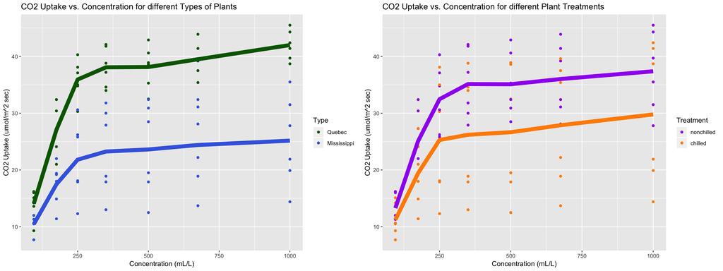

```r
# Creates a scatter plot mapping uptake to concentration, and then draws two lines across the graph representing the average uptake for each Type at each concentration.
mycolors <- c("darkgreen", "royalblue")
plot1 <- ggplot() + geom_point(data = CO2, mapping = aes(conc, uptake, color=Type)) +
  geom_line(data = mean_type_q, mapping = aes(conc, mean_up), color = "darkgreen", size = 3) +
  geom_line(data = mean_type_m, mapping = aes(conc, mean_up), color = "royalblue", size = 3) +
  scale_colour_manual(name = "Type", values = mycolors) +
  ggtitle("CO2 Uptake vs. Concentration for different Types of Plants") +
  labs(x = "Concentration (mL/L)", y = "CO2 Uptake (umol/m^2 sec)")

# Creates a scatter plot mapping uptake to concentration, and then draws two lines across the graph representing the average uptake for each Treatment at each concentration.
mycolors2 <- c("purple", "darkorange")
plot2 <- ggplot() + geom_point(data = CO2, mapping = aes(conc, uptake, color=Treatment)) +
  geom_line(data = mean_treat, mapping = aes(conc, mean_up), color = "darkorange", size = 3) +
  geom_line(data = mean_treat_un, mapping = aes(conc, mean_up), color = "purple", size = 3) +
  scale_colour_manual(name = "Treatment", values = mycolors2) +
  ggtitle("CO2 Uptake vs. Concentration for different Plant Treatments") +
  labs(x = "Concentration (mL/L)", y = "CO2 Uptake (umol/m^2 sec)")

# Places the two plots next to each other for easy visualization
cowplot::plot_grid(plot1, plot2, ncol=2)
```

### Summary

Both graphs above compare the CO2 uptake and concentration. The figure on the left is colored by Type, and the lines connect the mean uptake at each concentration for each type. The average CO2 uptake is higher for plants from Quebec than plants from Mississippi at all concentrations. The graph on the right is colored by Treatment, and the lines connect the mean uptake at each concentration for each treatment. The average CO2 uptake is higher for plants that had the nonchilled treatment at all concentrations. By looking at the individual data points at each concentration, it appears that most all plants from Quebec have higher uptake at every concentration as compared to Mississippi plants. However, looking at the figure on the right, it appears that the chilled points are varied for each concentration, having some plants with higher uptake values than some of the nonchilled treated plants, even though the average for the nonchilled is consistently higher. While uptake depends on both Type and Treatment, the relationship between uptake and Type appears to be more significant than with Treatment. As a next step, it would be interesting to look at this relationship with plants from more locations, since the type seems to have a distinct effect on the CO2 uptake of the plants.

## Dataset 2: UKLungDeaths

The `UKLungDeaths` dataset in R is titled **Monthly Deaths from Lung Diseases in the UK**. The source of this data is table A.3 in *Time Series: A Biostatistical Introduction*. This dataset contains three time series objects giving monthly deaths in the UK during the time 1974-1979 from three diseases: bronchitis, emphysema, and asthma. The three time series are called `mdeaths`, `fdeaths`, and `ldeaths`, which describe the monthly deaths of males, females, and both genders, respectively. These datasets each have 72 observations: 12 observations for 6 years. The first few lines of the `mdeaths` dataset are shown in the table below.

```r
# Converts the data from time series to data frame
mdeaths2 <- data.frame(matrix(mdeaths, ncol=frequency(mdeaths), dimnames=dimnames(.preformat.ts(mdeaths))))
fdeaths2 <- data.frame(matrix(fdeaths, ncol=frequency(fdeaths), dimnames=dimnames(.preformat.ts(fdeaths))))
ldeaths2 <- data.frame(matrix(ldeaths, ncol=frequency(ldeaths), dimnames=dimnames(.preformat.ts(ldeaths))))
mdeaths2 %>% kable(align = c("c", "c"))
```

|  | Jan | Feb | Mar | Apr | May | Jun | Jul | Aug | Sep | Oct | Nov | Dec |
| --- | --- | --- | --- | --- | --- | --- | --- | --- | --- | --- | --- | --- |
| 1974 | 2134 | 1280 | 2103 | 1186 | 2020 | 1113 | 2240 | 1087 | 2019 | 1098 | 2263 | 1056 |
| 1975 | 1863 | 1131 | 2137 | 1133 | 2750 | 970 | 1634 | 1013 | 2284 | 1004 | 1820 | 975 |
| 1976 | 1877 | 1209 | 2153 | 1053 | 2283 | 999 | 1722 | 959 | 1942 | 970 | 1846 | 940 |
| 1977 | 1877 | 1492 | 1833 | 1347 | 1479 | 1208 | 1801 | 1179 | 1423 | 1140 | 1531 | 1081 |
| 1978 | 1492 | 1621 | 1403 | 1545 | 1189 | 1467 | 1246 | 1229 | 1340 | 1110 | 1215 | 1294 |
| 1979 | 1249 | 1846 | 1288 | 2066 | 1160 | 2059 | 1162 | 1655 | 1187 | 1812 | 1075 | 1341 |

### Data Manipulation

The data manipulation of these datasets will combine both of the individual gendered datasets into one, while keeping track of which original dataset each observation came from. The data is also turned into a ‘long’ dataset for ease of visualization.

```r
# Labels each data set by gender, then converts them to "long" datasets
mdeaths_long <- mdeaths2 %>% rownames_to_column("Year") %>%
  mutate(gender = "M") %>%
  gather(key = Month, value = Deaths, -Year, -gender)

fdeaths_long <- fdeaths2 %>% rownames_to_column("Year") %>%
  mutate(gender = "F") %>%
  gather(key = Month, value = Deaths, -Year, -gender)

ldeaths_long <- ldeaths2 %>% rownames_to_column("Year") %>%
  mutate(gender = "L") %>%
  gather(key = Month, value = Deaths, -Year, -gender)

# Combines two long datasets into one data frame
total_deaths <- bind_rows(mdeaths_long, fdeaths_long)
```

### Figures

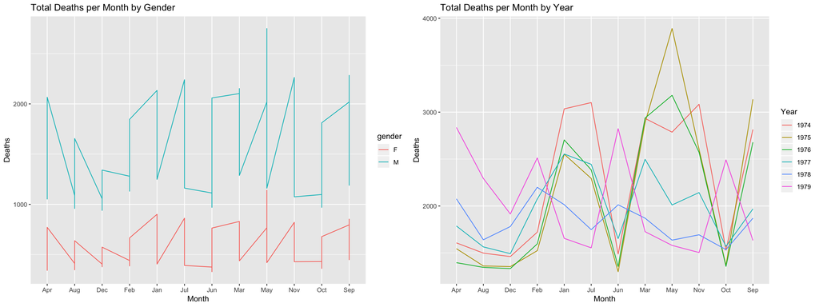

```r
# Creates two lines which connect the observations for number of deaths per month for each gender
plot1 <- ggplot(data = total_deaths) +
  geom_line(aes(Month, Deaths, group = gender, color = gender)) +
  ggtitle("Total Deaths per Month by Gender")

# Creates two lines which connect the observations for number of deaths per month for each year
plot2 <- ggplot(data = ldeaths_long) +
  geom_line(aes(Month, Deaths, group = Year, color = Year)) +
  ggtitle("Total Deaths per Month by Year")

# Places the two plots next to each other for easy visualization
cowplot::plot_grid(plot1, plot2, ncol=2)
```

### Summary

The figures above compare the total deaths from lung disease per month first by gender and then by year. The figure on the left shows that the number of deaths per month across all years in females are lower than the number of deaths in males. The vertical lines at each month represent the change in that month across years. The deaths in males seem to have a larger variance from year to year than the females, as the deaths range from 1,000 to over 2,000 deaths per month, as opposed to less than 1,000 for females. This variation in per year leads into the figure on the right, which compares the number of deaths per month by year, regardless of gender. It appears that all years have certain months that with higher deaths and others with lower deaths. Most years followed similar patterns, with the expception of 1979, which seems to have patterns opposite of the previous years. For example, the number of deaths in June for 1974-1978 are all under 2,000, but for 1979, it is over 2,500. An interesting next step for this dataset would be to look into factors that could account for why the number of deaths deviated from its usual patterns in 1979 as compared to the previous years. Additionally, a breakdown of which deaths were caused by bronchitis, emphysema, and asthma would be interesting visualize.

## Dataset 3: sleep

The `sleep` dataset in R is titled **Student’s Sleep Data**. This data came from *The action of optimal isomers: II hyoscines*. The dataset has 20 rows and 3 columns. The variables include the patient ID, the Drug Given, and the Numeric Increase in Hours of Sleep. In this experiment, two drugs were being compared, and each drug was given to the same ten patients. The first few lines of the dataset are shown in the table below.

```r
head(sleep) %>% kable(align = c("c", "c"))
```

| extra | group | ID |
| --- | --- | --- |
| 0.7 | 1 | 1 |
| -1.6 | 1 | 2 |
| -0.2 | 1 | 3 |
| -1.2 | 1 | 4 |
| -0.1 | 1 | 5 |
| 3.4 | 1 | 6 |

### Data Manipulation

The data manipulation of the`sleep` dataset separates the data by treatment given, and then summarizes the proportion of each treatment group who had an increase in sleep of more than one hour.

```r
# Groups the dataset by drug group and summarizes the proportion of patients that had an increase in sleep greater than 1 hour
table <- sleep %>% group_by(group) %>% summarise(proportion = sum(extra>1)/n())
kable(table, caption="Proportion of Patients who saw an Increase in Sleep of More than 1 Hour", align = c("c", "c"))
```

Proportion of Patients who saw an Increase in Sleep of More than 1 Hour

| group | proportion |
| --- | --- |
| 1 | 0.3 |
| 2 | 0.7 |

### Figures

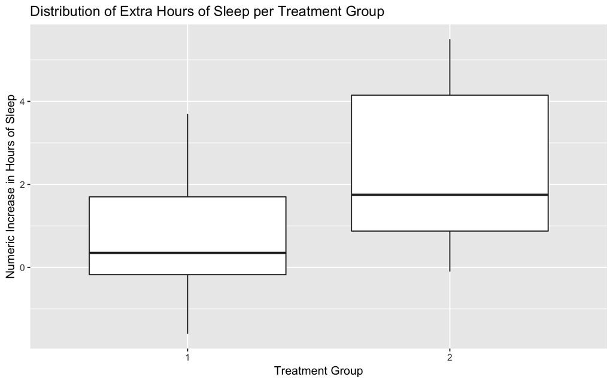

```r
# Creates boxplots for each drug group to look at the distribution for extra hours of sleep gained
ggplot(data=sleep) + geom_boxplot(mapping = aes(group, extra)) +
  ggtitle("Distribution of Extra Hours of Sleep per Treatment Group") +
  labs(x = "Treatment Group", y = "Numeric Increase in Hours of Sleep")
```

### Summary

As shown in the table under the Data Manipulation section, the group with drug 1, only 30% of the patients had a sleep increase of more than one hour, while for the drug 2, a much higher proportion of 70% had that increase. This leads to the belief that drug 2 is a more effective soporific drug. The figure above confirms this fact by visually comparing the distributions of the two drugs. Specifically, it appears that about 75% of the patients given drug 1 have an increase in sleep less than the median of the increase in sleep for when they were given drug 2. An interesting next step for this data would be to perform some statistical tests to see whether this visual difference in the drug effect on sleep is actually significant.

## Dataset 4: infert

The `infert` dataset in R is titled **Infertility after Spontaneous and Induced Abortion**. The original data source is *Br. J. of Obst. and Gynaec*. The dataset has 248 rows and 8 columns from a matched case-control study, and the variables include education, age, parity, number of prior induced abortions, case status, number of prior spontaneous abortions, matched set number, and stratum number. The first few lines of the dataset are shown in the table below.

```r
head(infert) %>% kable(align = c("c", "c"))
```

| education | age | parity | induced | case | spontaneous | stratum | pooled.stratum |
| --- | --- | --- | --- | --- | --- | --- | --- |
| 0-5yrs | 26 | 6 | 1 | 1 | 2 | 1 | 3 |
| 0-5yrs | 42 | 1 | 1 | 1 | 0 | 2 | 1 |
| 0-5yrs | 39 | 6 | 2 | 1 | 0 | 3 | 4 |
| 0-5yrs | 34 | 4 | 2 | 1 | 0 | 4 | 2 |
| 6-11yrs | 35 | 3 | 1 | 1 | 1 | 5 | 32 |
| 6-11yrs | 36 | 4 | 2 | 1 | 1 | 6 | 36 |

### Data Manipulation

The data manipulation of the `infert` dataset selects specific columns of the data to compare graphically. Then the data is converted into a correlation matrix, and is turned into a ‘long’ dataset so it is easier to graph. The purpose of this set of manipulations is to create the figure below.

```r
# Selects certain variables to create a correlation matrix
infert_new <- infert %>% select(induced, spontaneous, case)
infert_corr <- cor(infert_new)

# Turned into a long dataset
infert_long <-
  as.data.frame(infert_corr) %>% rownames_to_column() %>%
  gather(key = variables, value = correlation, -rowname)
```

### Figures

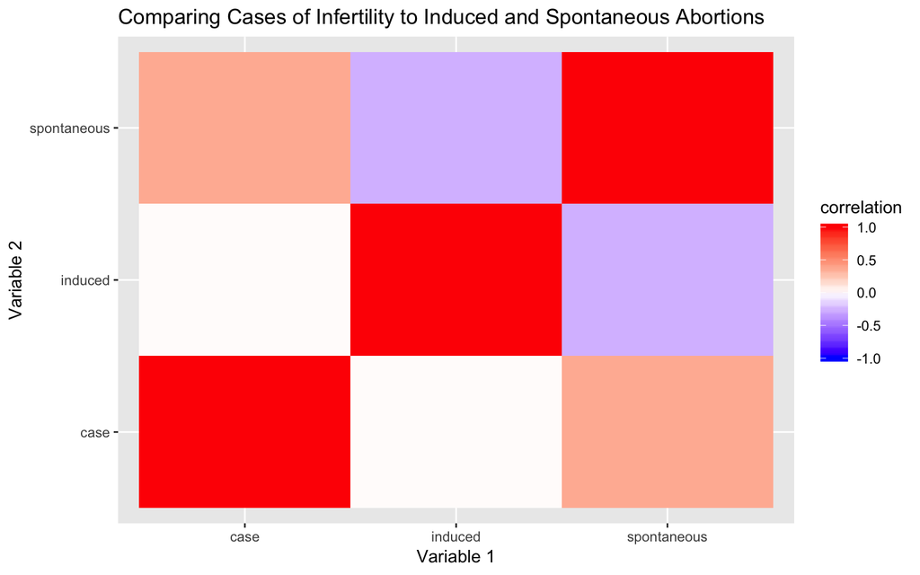

```r
# Creates a correlation heat map between the different types of abortions and whether or not they were infertile
ggplot(data = infert_long, mapping = aes(x = rowname, y = variables)) +
  geom_tile(mapping = aes(fill = correlation)) +
  scale_fill_gradient2(low = "blue", high = "red", mid = "white", midpoint = 0, limit = c(-1,1), space = "Lab") +
  labs(x = "Variable 1", y = "Variable 2") + ggtitle("Comparing Cases of Infertility to Induced and Spontaneous Abortions")
```

### Summary

This correlation heat map above shows the pairwise correlations between case, induced abortions, and spontaneous abortions. The plot shows that there is a slight positive correlation between case and spontaneous abortions, meaning that infertility is associated with more **spontaneous** abortions in this study. It appears that infertility has no correlation to the number of **induced** abortions. Additionally there is a slight negative correlation between the two types of abortions, meaning those patients with more induced abortions generally had less spontaneous abortions. An interesting next step for this dataset would be to look at the matchs of cases and controls and see if the relationships found in the heat map could be confounded by another varible like age or education.